Mr Custos, Mr Opponent, ladies and gentlemen,

Translation studies is a multi-faceted discipline with a large spectrum of different research topics and methods. My own interests have been, frankly, not in the absolute mainstream of this field. The focus of my dissertation in particular and my work as a researcher in general has not been, for instance, translating as a profession or the sociological aspects of working as an interpreter, but rather two languages and their differences on the level of grammar. It is my conviction that although the work that has been done in studying different phenomena surrounding the work of translators is valuable, we ought not to forget about the more linguistically oriented work that concentrates on the actual substance of translations, that is, the languages involved.

The part of linguistics that is especially relevant for translation studies has traditionally been called contrastive linguistics, that is the close comparison of two or more languages, usually with respect to a certain quality or phenomenon. Conducting contrastive research – as well as linguistics in a more general sense – has experienced a rather large shift during the last couple of decades. With the advent of large digitalized collections of texts – usually referred to as *corpora* – new possibilities have arisen and with the available corpora becoming larger and larger in size the nature of these possibilities has also changed. With regard to these possibilities and their implications to translation studies there are two points I would like to make.

The first point – which has been true for quite some time – is that we can now work in the direction of moving from observations to generalisations. That is, we can more realistically describe linguistic phenomena on the basis of real world data, not just by introspection. The second point is that we can also study phenomena that cannot be easily presented with a set of predefined rules – in general, phenomena that are usually considered fuzzy or hard to get a hold on. One such phenomenon is the theme of my dissertation, the comparison of word order in languages where it has traditionally been considered free.

Let me give an illustration of how this works by using one of the questions addressed in the dissertation. Imagine a teacher teaching Finnish for students whose first language is Russian. A student has written a text – say, the assignment was to write an email – with the following beginning [SCREEN]:

> Eilen minä puhuin Kallen kanssa uudesta työpaikastani. Hän oli innoissaan…

Now, the teacher might give a comment about the beginning of the email, saying something isn’t quite right with it. She might say you probably shouldn’t put the adverbial in the beginning, although she probably cannot really explain why. Or it might be the case that the teacher cannot even define what it is that is not “quite right” with the text.

Now, with an empirical approach and explicit comparison of two languages we can, first of all, find means of explaning why a certain construction does not “sound” right even though it is perfectly grammatical. Secondly, we are able to higlight some potential things you should be looking at when writing in your weaker language. That is, we can move the teachers and the learners towards using patterns that are known to be idiomatic. Instead of giving them a bucket full of lego blocks and instructions on how to attach individual blocks to one another we can show them examples of what is already known to look good and work and what is used frequently.

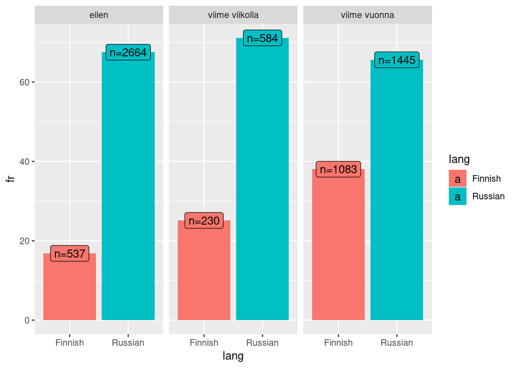

So, going back to the example on the screen and its connection to my dissertation. In one part of the thesis I make a comparison of three Finnish and Russian temporal expressions: viime vuonna, viime viiikolla and eilen. It turns out that these three have quite different usage patterns in Finnish and Russian. If we look at the Russian вчера, we can say that of a total of around 4000 Russian SVO sentences it is used in the beginning in about 2500 cases (more than 60%). Of a total of 3000 Finnnish sentences, on the other hand, only about 500 (less than 20%) have the adverbial in the beginning. The difference between the languages is more than 40 percents (on the screen). I will not go into the statistical details here. For the purposes of the current presentation, suffice it to say that the differences get smalller, if we compare “last week” and still smaller if we compare “last year.”.

So, when we look at sentences in isolation, the interlingual differences tend to look rather fuzzy and hard to explain, perhaps to the extent that one begins to doubt wether or not there even is any difference at all. Going back to the example on the screen, the teacher might not have any good way of describing why a particular example with a sentence-initial *eilen* doesn’t sound quite right in Finnish or why a Russian student would write such a sentence in the first place. However, when we take a broader look at the usage of time adverbials in a large dataset, we can get clues on what kind of patterns are frequent and what are not. Clearly, the usage of vthsera at the beginning of the sentence forms a pattern that is not as strongly present in Finnish with the Finnish *eilen*. On the other hand, since the differences between Finnish and Russian are smaller when it comes to *last week* and especially *last year*, we can also discern that the patterns that are more frequent in Russian are at least somewhat peculiar to vtshera. Going back to the example, thinking about what is not quite right with the student’s sentence, the teacher can at least say, that these kind of sentences seem to be more typical in Russian than in Finnish and simply inform the student that this is a fact he should be aware of when writing in Finnish.

These kind of discoveries, however, pose a challenge to the researcher. Finding empirical differences between two languages is, of course, already a valuable insight by itself – an insight that is beneficial from the perspective of language learners and, specifically, translators. Having knowledge about the frequency of different usage patterns is the type of skill that I don’t think is discussed enough in translator education and should be encouraged. Nonetheless, general observations about the existence of these differences can only get us so far: it is another task to try to account for *why* it is the case that, for instance, the sentence-initial vtshera is so much more frequent in Russian than the sentence-initial eilen in Finnish.

In trying to accomplish this task I have found it useful to make a distinction between what is sometimes called in the methodological literature direct and indirect evidence. The word orders of Finnish and Russian mostly serve pragmatic purposes, which means that by, for instance, positioning a time expression in location A rather than location B, the speaker or writer makes a choice about how to package information and in what tone or style he or she wants to deliver the information to his interlocutor or reader. The problem is, that these kind of choices are rather difficult to track down automatically for statistical analysis. About the only way to get *direct* evidence about the information packaging of a sentence would be to have somebody manually annotate the data for such notions as topic and focus or the activation states of different referents.

One of the hypotheses I make in the dissertation concerning the question about why the sentence-inital vtshera is so frequent in Russian is that in Russian it is a typical strategy to construct a text by starting a whole sequence with a time adverbial. I have labelled these kind of usage patterns introductory  
construcions, of which you can see one example on the screen:

> Вчера вторая ракетка Открытого чемпионата Франции Мария Шарапова провела свой первый матч на парижских грунтовых кортах. (RuPress: Советский спорт)

Now if the hypothesis is that these kind of sentences are more typical for Russian than for Finnish, how could we characterize them? Clearly, an important feature is that since they are located at the beginning of a new sequence – usually a whole news story like in this case or some new episode in a narrative text – they should contain words that refer to things new to the reader. Or, to be more precise, they should contain referents that the reader is unaware of, that is, not thinking about at the moment of reading the sentence. So, one could probably test the hypothesis about the prevalence of the introductory construction by testing how often a sentence-initial vtshera is accompanied by referents that reader is not already thinking about.

This is the crucial methodological point to make. How *can* you test such a thing as wether or not a person is probably thinking about a referent at the moment of reading a sentence – especially when trying to analyze large masses of texts and not isolated examples? As mentioned, one way would be to have the texts annotated, so that someone would actually have read each sentence and then manually marked some words as referring to entities a potential reader is not thinking about. That would, however, be not only tedious, time-consuming and difficult, but also rather unreliable. And this is where the usage of indirect evidence can be of great help.

In my thesis I assess the introductory construction hypothesis by looking at two kinds of indirect evidence concerning the novelty of the referents in a sentence. First, I analyze the length of subjects: my conclusion is that if a subject of a sentence consists of several words (like in the example on the screen) it is more likely to be referring to entities that have not yet been presented to the reader, whereas when a subject consists of only one word (say, if the example would have been just “Sharapova” or even more obviously “she”) it is probably something that has just been mentioned. Secondly, I take a look at the presence of certain kinds of verbs in a sentence with the assumption that words like *publish, announce, declare* and similar give a clue about something new being presented to the reader.

When looking at Finnish and Russian examples with eilen or vtshera with the help of this kind of indirect evidence, one can make some interesting observations that take us further than just the initial finding about there being a difference in how often these expressions are used sentence-initally. Namely, it does seem to be the case that having a multi-word subject like in the example above or a verb like *publish* increases the probability of using the sentence-initial location in Russian compared to Finnish. Again, the actual statistical models for testing these differences can be found in the thesis, but just as a quick overview let me mention some of the relevant percentages:

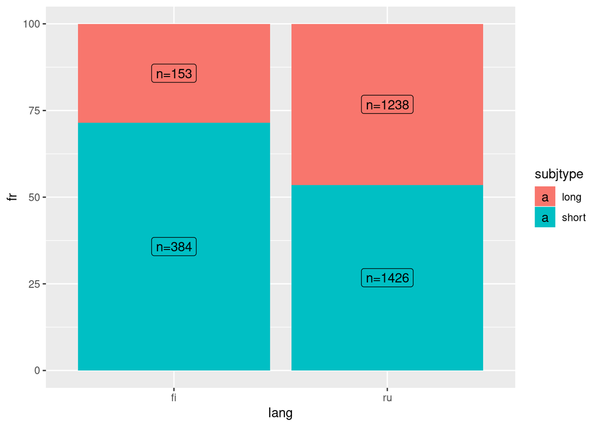

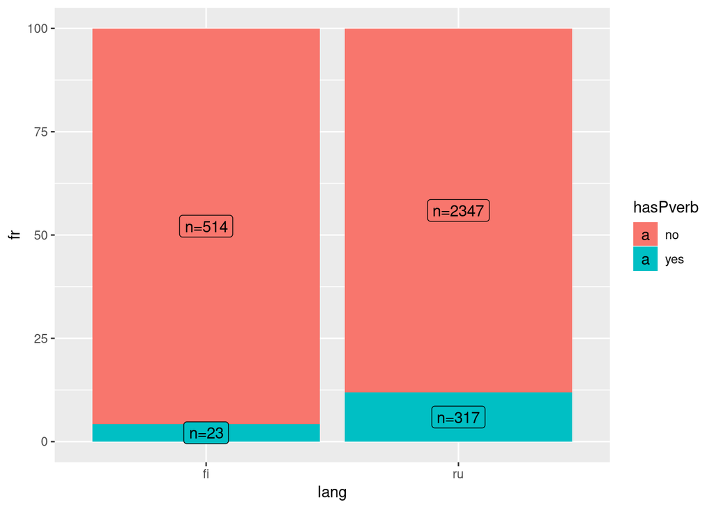

My point here is not, however, to give a detailed description of the findings in my disertation, but rather to demonstrate the usefullness of certain kinds of empirical approaches in explaining interlingual differences that cannot be given clear-cut definitions or boundaries. The location of adverbials of time in Finnish and Russian are a prime example of such a case. Looking at these kind of phenomena from a birds-eye perspective using large amounts of data and trying to establish patterns, probabilities and tendencies is something that I think should become an integral part of training tranlators and interpreters and other multilingual communicators that are usually dealing with a specific pair or some specific pairs of langauges. After all, the argument can be made that linguistic knowledge in general is statistical by nature: that is even L1 learners have been shown to be sensitive to frequencies and storing in their memory not just information about what a certain word or expression is but also about when and how often it is used.

So, in summary, what I have wanted to achieve with my dissertation project (and more generally as a researcher) is to collect information about the differences between Finnish and Russian. This aim has been quite practical in nature: to find out concrete use cases that can be used as a reference when thinking about the different possible locations of time expressions. As a result of the project I have produced concrete information about how one should change his or her ways of constructing discourse and ways of thinking about texts when writing or speaking in another language. This is the kind of information I myself found valuable when studying and it is my humble wish that the work I have produced in the form of the dissertation would become a source of this type of knowledege for anyone else working with the same kind of problems.

Mr Opponent, I now call upon you to present your critical comments on my dissertation.